# class_15

caroline iacuaniello

May 23, 2018

# source(“http://bioconductor.org/biocLite.R”)

# For this class, you’ll also need DESeq2:

biocLite(“DESeq2”)

```r
# source("http://bioconductor.org/biocLite.R")
# biocLite()

# For this class, you'll also need DESeq2:
# biocLite("DESeq2")
```

Load data files

```r
metaFile <- "GSE37704_metadata.csv"
countFile <- "GSE37704_featurecounts.csv"

# Import metadata and take a peak
colData = read.csv(metaFile, row.names=1)
head(colData)
```

```
##               condition
## SRR493366 control_sirna
## SRR493367 control_sirna
## SRR493368 control_sirna
## SRR493369      hoxa1_kd
## SRR493370      hoxa1_kd
## SRR493371      hoxa1_kd
```

```r
# Import countdata
countData = read.csv(countFile, row.names=1)
head(countData)
```

```
##                 length SRR493366 SRR493367 SRR493368 SRR493369 SRR493370
## ENSG00000186092    918         0         0         0         0         0
## ENSG00000279928    718         0         0         0         0         0
## ENSG00000279457   1982        23        28        29        29        28
## ENSG00000278566    939         0         0         0         0         0
## ENSG00000273547    939         0         0         0         0         0
## ENSG00000187634   3214       124       123       205       207       212
##                 SRR493371
## ENSG00000186092         0
## ENSG00000279928         0
## ENSG00000279457        46
## ENSG00000278566         0
## ENSG00000273547         0
## ENSG00000187634       258
```

# need to remove column “length” becauses need countDAta and colData files to match

```r
countData <- as.matrix(countData[,-1])
head(countData)
```

```
##                 SRR493366 SRR493367 SRR493368 SRR493369 SRR493370
## ENSG00000186092         0         0         0         0         0
## ENSG00000279928         0         0         0         0         0
## ENSG00000279457        23        28        29        29        28
## ENSG00000278566         0         0         0         0         0
## ENSG00000273547         0         0         0         0         0
## ENSG00000187634       124       123       205       207       212
##                 SRR493371
## ENSG00000186092         0
## ENSG00000279928         0
## ENSG00000279457        46
## ENSG00000278566         0
## ENSG00000273547         0
## ENSG00000187634       258
```

# now want to get rid of all zero entries

```r
# Filter count data where you have 0 read count across all samples.
countData = countData[rowSums(countData)>1, ]
head(countData)
```

```
##                 SRR493366 SRR493367 SRR493368 SRR493369 SRR493370
## ENSG00000279457        23        28        29        29        28
## ENSG00000187634       124       123       205       207       212
## ENSG00000188976      1637      1831      2383      1226      1326
## ENSG00000187961       120       153       180       236       255
## ENSG00000187583        24        48        65        44        48
## ENSG00000187642         4         9        16        14        16
##                 SRR493371
## ENSG00000279457        46
## ENSG00000187634       258
## ENSG00000188976      1504
## ENSG00000187961       357
## ENSG00000187583        64
## ENSG00000187642        16
```

# setup DESeqDataSet required for DESeq()

```r
dds = DESeqDataSetFromMatrix(countData=countData,
                             colData=colData,
                             design=~condition)
# condition is what comparing across
# run DE analysis
dds = DESeq(dds)
```

# next extract results table

```r
res <- results(dds, alpha = 0.05, lfcThreshold = 2)
res
```

```
## log2 fold change (MLE): condition hoxa1 kd vs control sirna
## Wald test p-value: condition hoxa1 kd vs control sirna
## DataFrame with 15280 rows and 6 columns
##                   baseMean log2FoldChange      lfcSE      stat    pvalue
##                  <numeric>      <numeric>  <numeric> <numeric> <numeric>
## ENSG00000279457   29.91358     0.17927483 0.32459294         0         1
## ENSG00000187634  183.22965     0.42644724 0.14017817         0         1
## ENSG00000188976 1651.18808    -0.69272061 0.05484412         0         1
## ENSG00000187961  209.63794     0.72975918 0.13178350         0         1
## ENSG00000187583   47.25512     0.04055411 0.27169055         0         1
## ...                    ...            ...        ...       ...       ...
## ENSG00000273748  35.302652      0.6743994  0.3034582         0         1
## ENSG00000278817   2.423024     -0.3889516  1.1295943         0         1
## ENSG00000278384   1.101796      0.3328870  1.6590966         0         1
## ENSG00000276345  73.644956     -0.3561673  0.2075751         0         1
## ENSG00000271254 181.595903     -0.6096640  0.1412340         0         1
##                      padj
##                 <numeric>
## ENSG00000279457         1
## ENSG00000187634         1
## ENSG00000188976         1
## ENSG00000187961         1
## ENSG00000187583         1
## ...                   ...
## ENSG00000273748         1
## ENSG00000278817         1
## ENSG00000278384        NA
## ENSG00000276345         1
## ENSG00000271254         1
```

```r
mcols(res, use.names = TRUE)
```

```
## DataFrame with 6 rows and 2 columns
##                        type
##                 <character>
## baseMean       intermediate
## log2FoldChange      results
## lfcSE               results
## stat                results
## pvalue              results
## padj                results
##                                                                description
##                                                                <character>
## baseMean                         mean of normalized counts for all samples
## log2FoldChange log2 fold change (MLE): condition hoxa1 kd vs control sirna
## lfcSE                  standard error: condition hoxa1 kd vs control sirna
## stat                   Wald statistic: condition hoxa1 kd vs control sirna
## pvalue              Wald test p-value: condition hoxa1 kd vs control sirna
## padj                                                  BH adjusted p-values
```

### Summarize results

```r
summary(res)
```

```
##
## out of 15280 with nonzero total read count
## adjusted p-value < 0.05
## LFC > 0 (up)     : 99, 0.65%
## LFC < 0 (down)   : 134, 0.88%
## outliers [1]     : 0, 0%
## low counts [2]   : 1482, 9.7%
## (mean count < 2)
## [1] see 'cooksCutoff' argument of ?results
## [2] see 'independentFiltering' argument of ?results
```

# change logfold change and p-value to get more manageable set-went up and edited results() to results(dds, alpha = 0.05, lfcThreshold = 2)

# use table function

```r
table(res$padj < 0.05)
```

```
##
## FALSE  TRUE
## 13565   233
```

```r
table(res$log2FoldChange > 2)
```

```
##
## FALSE  TRUE
## 14723   557
```

# combine the two to see how many genes meet both the 2logfold change and 0.05 pvalue

```r
table( res$padj < 0.05, res$log2FoldChange > 2)
```

```
##
##         FALSE  TRUE
##   FALSE 13292   273
##   TRUE    134    99
```

# p values below 0.05

```r
table(res$pvalue < 0.05)
```

```
##
## FALSE  TRUE
## 14954   326
```

# BH adjusted p-values, (in brief, this method calculates for each gene an adjusted p value that answers the following question: if one called significant all genes with an adjusted p value less than or equal to this gene’s adjusted p value threshold, what would be the fraction of false positives (the false discovery rate, FDR) among them, in the sense of the calculation outlined above? )

```r
table(res$padj < 0.05)
```

```
##
## FALSE  TRUE
## 13565   233
```

# subset genes with adjusted p values, sort by log2fold change, trying to get genes with strongest down regulation

```r
# Make a new results object 'resSig' with only significant genes
resSig <- subset(res, padj < 0.05)
```

```r
# Print the first 10 strongest DOWN genes
ord.down <- order(resSig$log2FoldChange)
head(resSig[ ord.down, ], 10)
```

```
## log2 fold change (MLE): condition hoxa1 kd vs control sirna
## Wald test p-value: condition hoxa1 kd vs control sirna
## DataFrame with 10 rows and 6 columns
##                  baseMean log2FoldChange     lfcSE       stat       pvalue
##                 <numeric>      <numeric> <numeric>  <numeric>    <numeric>
## ENSG00000152779  20.47585      -4.159774 0.6372338  -3.389295 7.007247e-04
## ENSG00000139269  34.67082      -3.707145 0.4489612  -3.802434 1.432814e-04
## ENSG00000100526 104.74410      -3.670758 0.2538387  -6.581965 4.642702e-11
## ENSG00000162520 248.71515      -3.522675 0.1645404  -9.254111 2.160200e-20
## ENSG00000117650 126.83830      -3.436330 0.2201916  -6.523092 6.887258e-11
## ENSG00000183287 603.48721      -3.436112 0.1129688 -12.712465 5.041941e-37
## ENSG00000013293 186.24913      -3.419521 0.1869698  -7.592247 3.144050e-14
## ENSG00000183763  46.40721      -3.398924 0.3586012  -3.901059 9.577266e-05
## ENSG00000157456 291.43640      -3.380308 0.1501209  -9.194645 3.762361e-20
## ENSG00000171320  49.47850      -3.368015 0.3462612  -3.950819 7.788429e-05
##                         padj
##                    <numeric>
## ENSG00000152779 4.259295e-02
## ENSG00000139269 9.643890e-03
## ENSG00000100526 6.536735e-09
## ENSG00000162520 6.931729e-18
## ENSG00000117650 9.599029e-09
## ENSG00000183287 3.864928e-34
## ENSG00000013293 5.633974e-12
## ENSG00000183763 6.955111e-03
## ENSG00000157456 1.128545e-17
## ENSG00000171320 5.746778e-03
```

```r
# Print the first 10 strongest UP genes
ord.up <- order(resSig$log2FoldChange, decreasing = TRUE)
head(resSig[ ord.up, ], 10)
```

```
## log2 fold change (MLE): condition hoxa1 kd vs control sirna
## Wald test p-value: condition hoxa1 kd vs control sirna
## DataFrame with 10 rows and 6 columns
##                   baseMean log2FoldChange     lfcSE      stat       pvalue
##                  <numeric>      <numeric> <numeric> <numeric>    <numeric>
## ENSG00000128052  158.24955       8.822086 1.0347214  6.593162 4.305562e-11
## ENSG00000141668   43.94156       8.820638 1.2040490  5.664751 1.472384e-08
## ENSG00000004799   97.26023       8.117454 1.0373919  5.896956 3.702688e-09
## ENSG00000109321 3907.19054       7.479166 0.2880675 19.020423 1.155483e-80
## ENSG00000162892   25.27893       7.052106 1.2210031  4.137669 3.508527e-05
## ENSG00000073756 1357.62707       6.337747 0.3399843 12.758671 2.789195e-37
## ENSG00000125845 1172.23868       5.525337 0.2077712 16.967397 1.431378e-64
## ENSG00000163739   89.96993       5.356228 0.8223964  4.081034 4.483576e-05
## ENSG00000163734   33.68060       5.218578 0.6984361  4.608263 4.060459e-06
## ENSG00000072041 2369.28278       5.097353 0.1868148 16.579804 9.754639e-62
##                         padj
##                    <numeric>
## ENSG00000128052 6.124551e-09
## ENSG00000141668 1.751376e-06
## ENSG00000004799 4.561579e-07
## ENSG00000109321 3.188670e-77
## ENSG00000162892 2.719700e-03
## ENSG00000073756 2.263842e-34
## ENSG00000125845 2.821451e-61
## ENSG00000163739 3.399142e-03
## ENSG00000163734 3.591424e-04
## ENSG00000072041 1.495495e-58
```

### Annotating genes and mapping to Entrez IDs

```r
#biocLite("org.Hs.eg.db")
library("AnnotationDbi")
library("org.Hs.eg.db")
columns(org.Hs.eg.db)
```

```
##  [1] "ACCNUM"       "ALIAS"        "ENSEMBL"      "ENSEMBLPROT"
##  [5] "ENSEMBLTRANS" "ENTREZID"     "ENZYME"       "EVIDENCE"
##  [9] "EVIDENCEALL"  "GENENAME"     "GO"           "GOALL"
## [13] "IPI"          "MAP"          "OMIM"         "ONTOLOGY"
## [17] "ONTOLOGYALL"  "PATH"         "PFAM"         "PMID"
## [21] "PROSITE"      "REFSEQ"       "SYMBOL"       "UCSCKG"
## [25] "UNIGENE"      "UNIPROT"
```

```r
#source("http://bioconductor.org/biocLite.R")
#biocLite(c("pathview", "gage", "gageData"))
```

```r
res$symbol = mapIds(org.Hs.eg.db,
                    keys=row.names(res),
                    column="SYMBOL",
                    keytype="ENSEMBL",
                    multiVals="first")
res$entrez = mapIds(org.Hs.eg.db,
                    keys=row.names(res),
                    column="ENTREZID",
                    keytype="ENSEMBL",
                    multiVals="first")
res$name =   mapIds(org.Hs.eg.db,
                    keys=row.names(res),
                    column="GENENAME",
                    keytype="ENSEMBL",
                    multiVals="first")
head(res, 10)
```

```
## log2 fold change (MLE): condition hoxa1 kd vs control sirna
## Wald test p-value: condition hoxa1 kd vs control sirna
## DataFrame with 10 rows and 9 columns
##                   baseMean log2FoldChange      lfcSE      stat    pvalue
##                  <numeric>      <numeric>  <numeric> <numeric> <numeric>
## ENSG00000279457   29.91358     0.17927483 0.32459294 0.0000000 1.0000000
## ENSG00000187634  183.22965     0.42644724 0.14017817 0.0000000 1.0000000
## ENSG00000188976 1651.18808    -0.69272061 0.05484412 0.0000000 1.0000000
## ENSG00000187961  209.63794     0.72975918 0.13178350 0.0000000 1.0000000
## ENSG00000187583   47.25512     0.04055411 0.27169055 0.0000000 1.0000000
## ENSG00000187642   11.97975     0.54275443 0.52117592 0.0000000 1.0000000
## ENSG00000188290  108.92213     2.05704993 0.19679801 0.2898908 0.7718998
## ENSG00000187608  350.71687     0.25737707 0.10267368 0.0000000 1.0000000
## ENSG00000188157 9128.43942     0.38990881 0.04673847 0.0000000 1.0000000
## ENSG00000131591  156.47908     0.19659758 0.14551980 0.0000000 1.0000000
##                      padj       symbol      entrez
##                 <numeric>  <character> <character>
## ENSG00000279457         1 LOC102723897   102723897
## ENSG00000187634         1       SAMD11      148398
## ENSG00000188976         1        NOC2L       26155
## ENSG00000187961         1       KLHL17      339451
## ENSG00000187583         1      PLEKHN1       84069
## ENSG00000187642         1        PERM1       84808
## ENSG00000188290         1         HES4       57801
## ENSG00000187608         1        ISG15        9636
## ENSG00000188157         1         AGRN      375790
## ENSG00000131591         1     C1orf159       54991
##                                                                     name
##                                                              <character>
## ENSG00000279457                        WAS protein family homolog 2-like
## ENSG00000187634                 sterile alpha motif domain containing 11
## ENSG00000188976 NOC2 like nucleolar associated transcriptional repressor
## ENSG00000187961                              kelch like family member 17
## ENSG00000187583                 pleckstrin homology domain containing N1
## ENSG00000187642             PPARGC1 and ESRR induced regulator, muscle 1
## ENSG00000188290                   hes family bHLH transcription factor 4
## ENSG00000187608                            ISG15 ubiquitin-like modifier
## ENSG00000188157                                                    agrin
## ENSG00000131591                      chromosome 1 open reading frame 159
```

```r
library(pathview)
library(gage)
library(gageData)
data(kegg.sets.hs)
data(sigmet.idx.hs)

kegg.sets.hs = kegg.sets.hs[sigmet.idx.hs]
head(kegg.sets.hs, 3)
```

```
## $`hsa00232 Caffeine metabolism`
## [1] "10"   "1544" "1548" "1549" "1553" "7498" "9"
##
## $`hsa00983 Drug metabolism - other enzymes`
##  [1] "10"     "1066"   "10720"  "10941"  "151531" "1548"   "1549"
##  [8] "1551"   "1553"   "1576"   "1577"   "1806"   "1807"   "1890"
## [15] "221223" "2990"   "3251"   "3614"   "3615"   "3704"   "51733"
## [22] "54490"  "54575"  "54576"  "54577"  "54578"  "54579"  "54600"
## [29] "54657"  "54658"  "54659"  "54963"  "574537" "64816"  "7083"
## [36] "7084"   "7172"   "7363"   "7364"   "7365"   "7366"   "7367"
## [43] "7371"   "7372"   "7378"   "7498"   "79799"  "83549"  "8824"
## [50] "8833"   "9"      "978"
##
## $`hsa00230 Purine metabolism`
##   [1] "100"    "10201"  "10606"  "10621"  "10622"  "10623"  "107"
```

[output cut: 23 more lines]

```r
foldchanges = res$log2FoldChange
names(foldchanges) = res$entrez
head(foldchanges)
```

```
##   102723897      148398       26155      339451       84069       84808
##  0.17927483  0.42644724 -0.69272061  0.72975918  0.04055411  0.54275443
```

```r
# Get the results
keggres = gage(foldchanges, gsets=kegg.sets.hs, same.dir=TRUE)
```

# Look at results

```r
attributes(keggres)
```

```
## $names
## [1] "greater" "less"    "stats"
```

# a list object

```r
head(keggres$greater)
```

```
##                                         p.geomean stat.mean       p.val
## hsa04640 Hematopoietic cell lineage   0.002709366  2.857393 0.002709366
## hsa04630 Jak-STAT signaling pathway   0.005655916  2.557207 0.005655916
## hsa04142 Lysosome                     0.008948808  2.384783 0.008948808
## hsa00140 Steroid hormone biosynthesis 0.009619717  2.432105 0.009619717
## hsa04740 Olfactory transduction       0.010846448  2.357877 0.010846448
## hsa04916 Melanogenesis                0.017613266  2.123151 0.017613266
##                                           q.val set.size        exp1
## hsa04640 Hematopoietic cell lineage   0.3470863       49 0.002709366
## hsa04630 Jak-STAT signaling pathway   0.3470863      103 0.005655916
## hsa04142 Lysosome                     0.3470863      117 0.008948808
## hsa00140 Steroid hormone biosynthesis 0.3470863       26 0.009619717
## hsa04740 Olfactory transduction       0.3470863       39 0.010846448
## hsa04916 Melanogenesis                0.4696871       85 0.017613266
```

```r
head(keggres$less)
```

```
##                                      p.geomean stat.mean        p.val
## hsa04110 Cell cycle               1.004024e-05 -4.353447 1.004024e-05
## hsa03030 DNA replication          8.909718e-05 -3.968605 8.909718e-05
## hsa03013 RNA transport            1.333746e-03 -3.038773 1.333746e-03
## hsa04114 Oocyte meiosis           2.496109e-03 -2.840329 2.496109e-03
## hsa03440 Homologous recombination 2.942017e-03 -2.868137 2.942017e-03
## hsa00240 Pyrimidine metabolism    5.800212e-03 -2.549616 5.800212e-03
##                                         q.val set.size         exp1
## hsa04110 Cell cycle               0.001606438      120 1.004024e-05
## hsa03030 DNA replication          0.007127774       36 8.909718e-05
## hsa03013 RNA transport            0.071133118      143 1.333746e-03
## hsa04114 Oocyte meiosis           0.094144560       98 2.496109e-03
## hsa03440 Homologous recombination 0.094144560       28 2.942017e-03
## hsa00240 Pyrimidine metabolism    0.138500584       95 5.800212e-03
```

```r
lapply(keggres, head)
```

```
## $greater
##                                         p.geomean stat.mean       p.val
## hsa04640 Hematopoietic cell lineage   0.002709366  2.857393 0.002709366
## hsa04630 Jak-STAT signaling pathway   0.005655916  2.557207 0.005655916
## hsa04142 Lysosome                     0.008948808  2.384783 0.008948808
## hsa00140 Steroid hormone biosynthesis 0.009619717  2.432105 0.009619717
## hsa04740 Olfactory transduction       0.010846448  2.357877 0.010846448
## hsa04916 Melanogenesis                0.017613266  2.123151 0.017613266
##                                           q.val set.size        exp1
## hsa04640 Hematopoietic cell lineage   0.3470863       49 0.002709366
## hsa04630 Jak-STAT signaling pathway   0.3470863      103 0.005655916
## hsa04142 Lysosome                     0.3470863      117 0.008948808
## hsa00140 Steroid hormone biosynthesis 0.3470863       26 0.009619717
## hsa04740 Olfactory transduction       0.3470863       39 0.010846448
## hsa04916 Melanogenesis                0.4696871       85 0.017613266
##
## $less
##                                      p.geomean stat.mean        p.val
## hsa04110 Cell cycle               1.004024e-05 -4.353447 1.004024e-05
## hsa03030 DNA replication          8.909718e-05 -3.968605 8.909718e-05
## hsa03013 RNA transport            1.333746e-03 -3.038773 1.333746e-03
## hsa04114 Oocyte meiosis           2.496109e-03 -2.840329 2.496109e-03
## hsa03440 Homologous recombination 2.942017e-03 -2.868137 2.942017e-03
## hsa00240 Pyrimidine metabolism    5.800212e-03 -2.549616 5.800212e-03
##                                         q.val set.size         exp1
## hsa04110 Cell cycle               0.001606438      120 1.004024e-05
## hsa03030 DNA replication          0.007127774       36 8.909718e-05
## hsa03013 RNA transport            0.071133118      143 1.333746e-03
## hsa04114 Oocyte meiosis           0.094144560       98 2.496109e-03
## hsa03440 Homologous recombination 0.094144560       28 2.942017e-03
## hsa00240 Pyrimidine metabolism    0.138500584       95 5.800212e-03
##
## $stats
##                                       stat.mean     exp1
## hsa04640 Hematopoietic cell lineage    2.857393 2.857393
## hsa04630 Jak-STAT signaling pathway    2.557207 2.557207
## hsa04142 Lysosome                      2.384783 2.384783
## hsa00140 Steroid hormone biosynthesis  2.432105 2.432105
## hsa04740 Olfactory transduction        2.357877 2.357877
## hsa04916 Melanogenesis                 2.123151 2.123151
```

```r
## Sanity check displaying all pathways data
pathways = data.frame(id=rownames(keggres$greater), keggres$greater)
head(pathways)
```

```
##                                                                          id
## hsa04640 Hematopoietic cell lineage     hsa04640 Hematopoietic cell lineage
## hsa04630 Jak-STAT signaling pathway     hsa04630 Jak-STAT signaling pathway
## hsa04142 Lysosome                                         hsa04142 Lysosome
## hsa00140 Steroid hormone biosynthesis hsa00140 Steroid hormone biosynthesis
## hsa04740 Olfactory transduction             hsa04740 Olfactory transduction
## hsa04916 Melanogenesis                               hsa04916 Melanogenesis
##                                         p.geomean stat.mean       p.val
## hsa04640 Hematopoietic cell lineage   0.002709366  2.857393 0.002709366
## hsa04630 Jak-STAT signaling pathway   0.005655916  2.557207 0.005655916
## hsa04142 Lysosome                     0.008948808  2.384783 0.008948808
## hsa00140 Steroid hormone biosynthesis 0.009619717  2.432105 0.009619717
## hsa04740 Olfactory transduction       0.010846448  2.357877 0.010846448
## hsa04916 Melanogenesis                0.017613266  2.123151 0.017613266
##                                           q.val set.size        exp1
## hsa04640 Hematopoietic cell lineage   0.3470863       49 0.002709366
## hsa04630 Jak-STAT signaling pathway   0.3470863      103 0.005655916
## hsa04142 Lysosome                     0.3470863      117 0.008948808
## hsa00140 Steroid hormone biosynthesis 0.3470863       26 0.009619717
## hsa04740 Olfactory transduction       0.3470863       39 0.010846448
## hsa04916 Melanogenesis                0.4696871       85 0.017613266
```

```r
pathview(gene.data=foldchanges, pathway.id="hsa04110")
```

```
## Info: Working in directory /Users/ruby/Desktop/bggn271/bggn213_github/class_15
```

```
## Info: Writing image file hsa04110.pathview.png
```

```r
#![](filenamehere) to have preview of picture to appear
```

# To generate PDF graph

```r
# A different PDF based output of the same data
pathview(gene.data=foldchanges, pathway.id="hsa04110", kegg.native=FALSE)
```

```
## Info: Working in directory /Users/ruby/Desktop/bggn271/bggn213_github/class_15
```

```
## Info: Writing image file hsa04110.pathview.pdf
```

[figure not shown]

```r
## Focus on top 5 upregulated pathways here for demo purposes only
keggrespathways <- rownames(keggres$greater)[1:5]

# Extract the IDs part of each string
keggresids = substr(keggrespathways, start=1, stop=8)
keggresids
```

```
## [1] "hsa04640" "hsa04630" "hsa04142" "hsa00140" "hsa04740"
```

```r
# Finally, lets pass these IDs in keggresids to the pathview() function to draw plots for all the top 5 pathways.

pathview(gene.data=foldchanges, pathway.id=keggresids, species="hsa")
```

```
## Info: Working in directory /Users/ruby/Desktop/bggn271/bggn213_github/class_15
```

```
## Info: Writing image file hsa04640.pathview.png
```

```
## Info: Working in directory /Users/ruby/Desktop/bggn271/bggn213_github/class_15
```

```
## Info: Writing image file hsa04630.pathview.png
```

```
## Info: Working in directory /Users/ruby/Desktop/bggn271/bggn213_github/class_15
```

```
## Info: Writing image file hsa04142.pathview.png
```

```
## Info: some node width is different from others, and hence adjusted!
```

[output not shown]

[output cut: 634 more lines]

[output not shown]

```
## Info: Working in directory /Users/ruby/Desktop/bggn271/bggn213_github/class_15
```

```
## Info: Writing image file hsa00140.pathview.png
```

```
## Info: Working in directory /Users/ruby/Desktop/bggn271/bggn213_github/class_15
```

```
## Info: Writing image file hsa04740.pathview.png
```

```
## Info: some node width is different from others, and hence adjusted!
```

Finally, lets pass these IDs in keggresids to the pathview() function to draw plots for all the top 5 pathways.

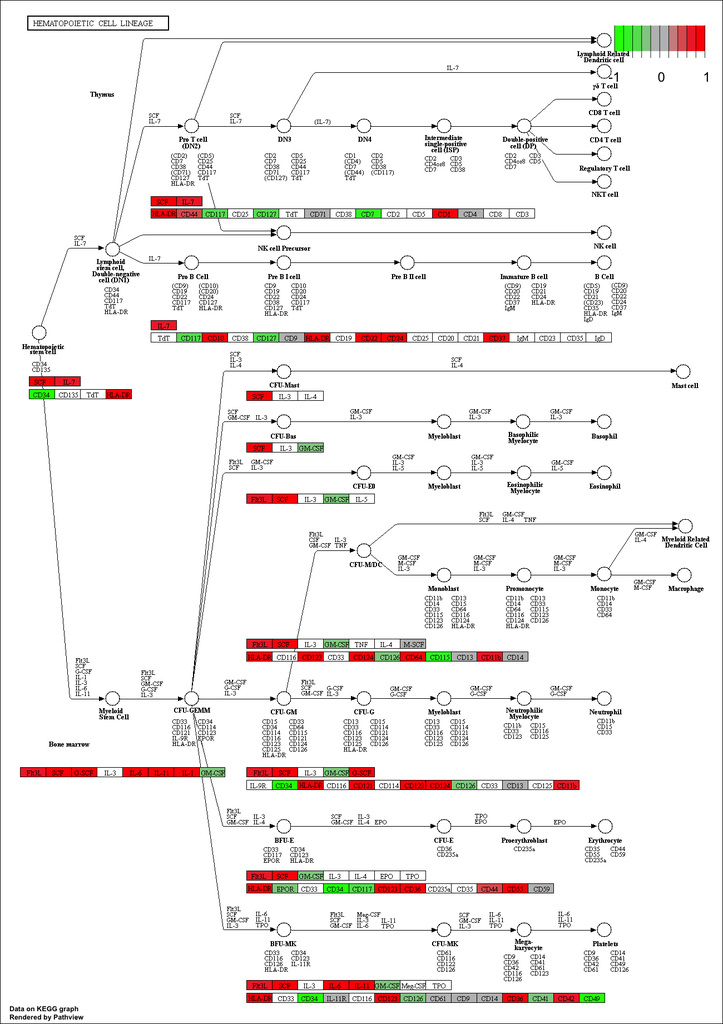

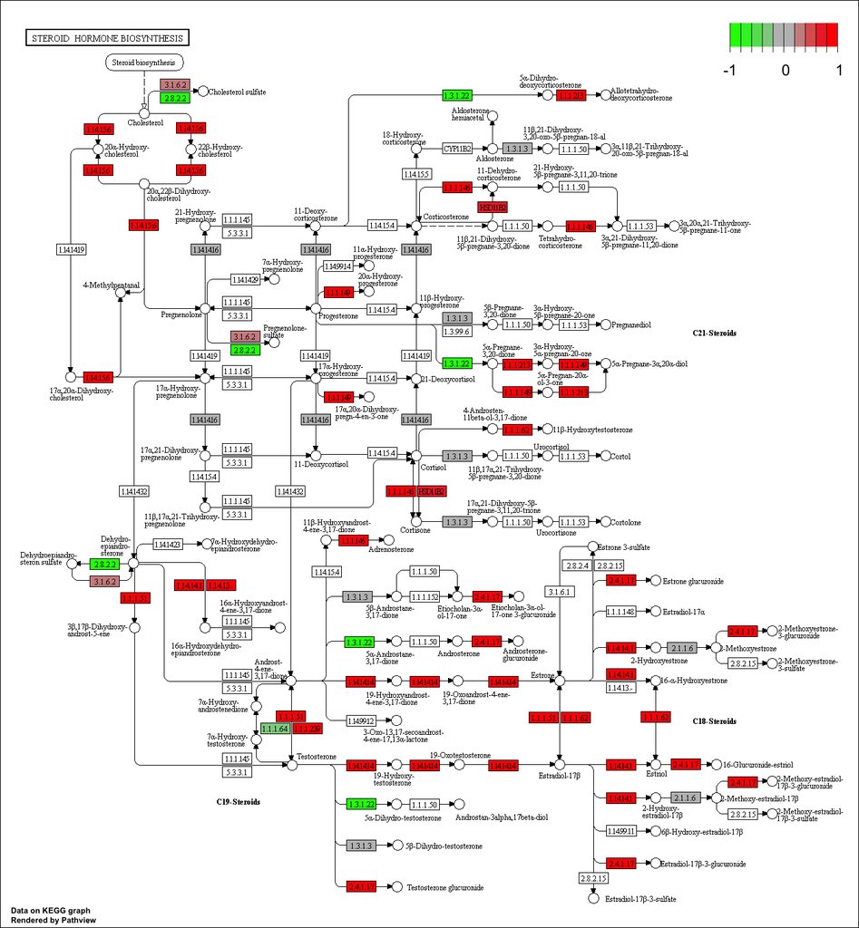

[figure not shown]

[figure not shown]

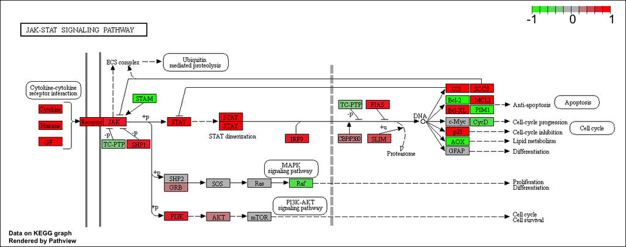

### Section 3, Gene ontology (GO)

```r
data(go.sets.hs)
data(go.subs.hs)
gobpsets = go.sets.hs[go.subs.hs$BP]

gobpres = gage(foldchanges, gsets=gobpsets, same.dir=TRUE)

lapply(gobpres, head)
```

```
## $greater
##                                              p.geomean stat.mean
## GO:0007156 homophilic cell adhesion       4.893044e-05  3.971869
## GO:0060429 epithelium development         6.727999e-05  3.834578
## GO:0007610 behavior                       2.171759e-04  3.534089
## GO:0048729 tissue morphogenesis           2.471263e-04  3.498950
## GO:0002009 morphogenesis of an epithelium 3.227727e-04  3.429293
## GO:0016337 cell-cell adhesion             8.194676e-04  3.163087
##                                                  p.val     q.val set.size
## GO:0007156 homophilic cell adhesion       4.893044e-05 0.1337863      107
## GO:0060429 epithelium development         6.727999e-05 0.1337863      478
## GO:0007610 behavior                       2.171759e-04 0.2457053      404
## GO:0048729 tissue morphogenesis           2.471263e-04 0.2457053      403
## GO:0002009 morphogenesis of an epithelium 3.227727e-04 0.2567334      326
## GO:0016337 cell-cell adhesion             8.194676e-04 0.3753986      318
##                                                   exp1
## GO:0007156 homophilic cell adhesion       4.893044e-05
## GO:0060429 epithelium development         6.727999e-05
## GO:0007610 behavior                       2.171759e-04
## GO:0048729 tissue morphogenesis           2.471263e-04
## GO:0002009 morphogenesis of an epithelium 3.227727e-04
## GO:0016337 cell-cell adhesion             8.194676e-04
##
## $less
##                                             p.geomean stat.mean
## GO:0000279 M phase                       1.475275e-16 -8.323757
## GO:0048285 organelle fission             7.498096e-16 -8.160310
## GO:0000280 nuclear division              2.135081e-15 -8.034815
## GO:0007067 mitosis                       2.135081e-15 -8.034815
## GO:0000087 M phase of mitotic cell cycle 5.927745e-15 -7.891754
## GO:0007059 chromosome segregation        1.055849e-11 -6.988384
##                                                 p.val        q.val
## GO:0000279 M phase                       1.475275e-16 5.867170e-13
## GO:0048285 organelle fission             7.498096e-16 1.490996e-12
## GO:0000280 nuclear division              2.135081e-15 2.122805e-12
## GO:0007067 mitosis                       2.135081e-15 2.122805e-12
## GO:0000087 M phase of mitotic cell cycle 5.927745e-15 4.714928e-12
## GO:0007059 chromosome segregation        1.055849e-11 6.998521e-09
##                                          set.size         exp1
## GO:0000279 M phase                            492 1.475275e-16
## GO:0048285 organelle fission                  373 7.498096e-16
## GO:0000280 nuclear division                   349 2.135081e-15
## GO:0007067 mitosis                            349 2.135081e-15
## GO:0000087 M phase of mitotic cell cycle      359 5.927745e-15
## GO:0007059 chromosome segregation             141 1.055849e-11
##
## $stats
##                                           stat.mean     exp1
## GO:0007156 homophilic cell adhesion        3.971869 3.971869
## GO:0060429 epithelium development          3.834578 3.834578
## GO:0007610 behavior                        3.534089 3.534089
## GO:0048729 tissue morphogenesis            3.498950 3.498950
## GO:0002009 morphogenesis of an epithelium  3.429293 3.429293
## GO:0016337 cell-cell adhesion              3.163087 3.163087
```

## Reactome pathway analysis

```r
sig_genes <- res[res$padj <= 0.05 & !is.na(res$padj), "symbol"]
print(paste("Total number of significant genes:", length(sig_genes)))
```

```
## [1] "Total number of significant genes: 233"
```

```r
write.table(sig_genes, file="significant_genes.txt", row.names=FALSE, col.names=FALSE, quote=FALSE)
```